# eNODAL

# Introduction

Experimental guided nutriomics data clustering(eNODAL) method is an R package that facilitates discovery of relationships among high dimensional omics features and complex experimental condition.

The method use a two-stage clustering method. At first stage, eNODAL using an ANOVA model to categorize omics features into several interpretable groups, in the second stage, eNODAL using consensus clustering method to further cluster each groups into sublcusters. The overall workflow of eNODAL shown in the following.

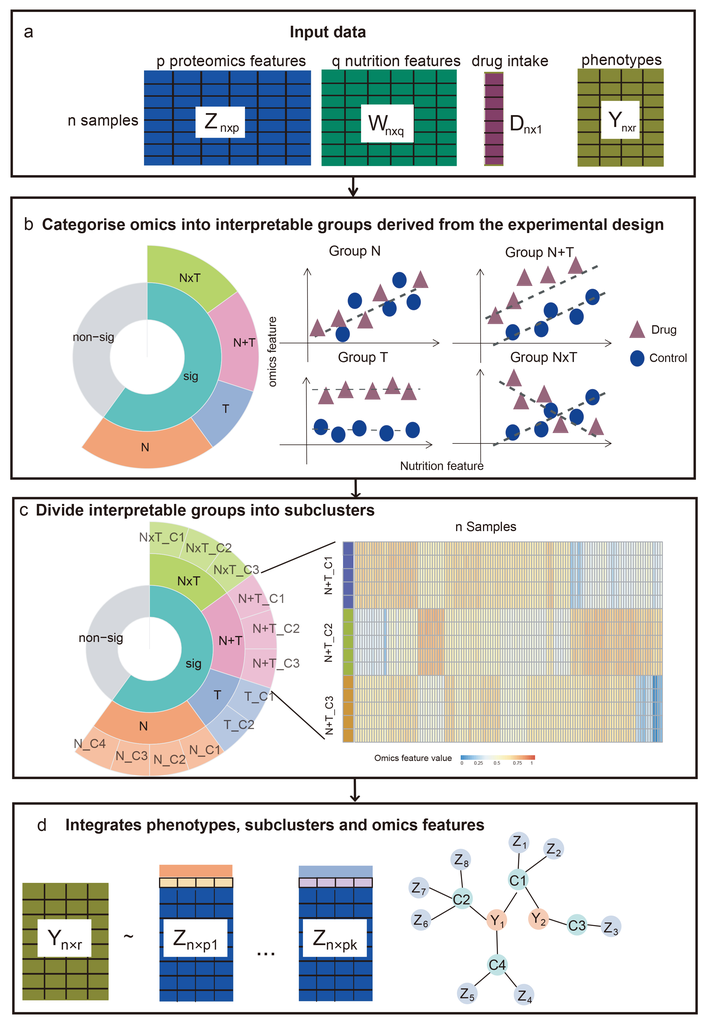

workflow

```r
library(eNODAL)
```

eNODAL use three modality as input, high dimensional omics features(Z), one set of experimental conditions, e.g. nutrition intake, denoted as Meta1 and another set of experimental conditions e.g. drug treatment, denoted as Meta2. Both of these factors can be (multiple) numerical variables or factors.

In this vignette, we go through a mouse liver proteomics data with different nutrition and drug treatment to analysis how nutrition and drug treatment influence these proteomics features.

# Mouse liver proteomics data

The `Proteomics` dataset contain data from a mouse liver proteomics study, the nutrition intake of each constructed from a combination of 10 types of diet and the amount of food and nutrition is measured. Each mouse takes one of four types of treatment, including control, metformin, rapamycin and resveratrol, resulting 40 combinations of complex experimental conditions.

For full dataset and raw dataset, please use `data(Proteomics_full)`

In this example, we simplified to first 1,000 proteomics and we will use eNODAL to categorize each proteomics feature interpretable group, significantly affected by 1) nutrition intake, 2) drug intake, 3) nutrition drug additive effect, 4) nutrition and drug interaction effect and 5) not signifcantly affected by all experimental conditions. Then eNODAL will further do consensus clustering for each interpretable group.

```r
data("Proteomics")
```

## Build the `eNODAL` object

First we build the `eNODAL` object, the input data to build `eNODAL` have three part: omics data(Z), experimental condition 1(Meta1) and experimental condition2(Meta2). (Meta1 and Meta2 better to be low dimensional). Meta1 and Meta2 can be both a vector or dataframe. Z can be a matrix or dataframe. For all of these data, each row is a sample and each column is a feature.

In the following example, we build `eNODAL` object based on data in `Proteomics`.

```r
Z <- Proteomics$Z
Meta1 <- Proteomics$Meta1
Meta2 <- Proteomics$Meta2
```

eNODAL object can also incorporate lots of parameters used in the hypothesis testing, consensus clustering. Especially, we implemented both linear model(lm) and general additive model(gam). Details of these parameters see `?createParams`. To accelerate the processing, we use all linear model to for testing.

```r
eNODAL_obj = eNODAL_build(Z = Z, Meta1 = Meta1, Meta2 = Meta2, sig_test = "lm", test_func = "lm")
```

### Run the `eNODAL`.

Now using the `runeNODAL` function, we can run `eNODAL` object with the specified parameters in the `eNODAL_build` or `createParams`.

```r
eNODAL_obj = runeNODAL(eNODAL_obj)
```

which is equivalent to the following code

eNODAL_obj = runHT(eNODAL_obj) eNODAL_obj = runSubclust(eNODAL_obj)

The clustering result can be got by

```r
Cl_df <- get_clusters(eNODAL_obj)
```

And the resulting cluster can be shown by

```r
show_clusters(eNODAL_obj)
```

[output not shown]

and can also be visualized by

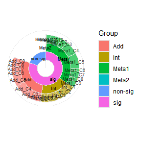

```r
ClusterPlot(eNODAL_obj)
```

# Visualization

In this section, we will show how to visualize relationships between omics feautures, (or resulting cluters) and continuous variables(nutrition intake) by nutrition geometry framewor and discrete variables(drug intake) by boxplot.

## Nutrition geometry framework(NGF)

Even we do not do `runeNODAL`, we can also run NGF based on selected omics features (can be both feature name or index). In the following example, we will illustrate the NGF of eNODAL object on protein `P19096` on “intake.P”, “intake.C” and “intake.F”. The resulting NGF will be any two combination of nutrition feature and the third one be the median.

[output not shown]

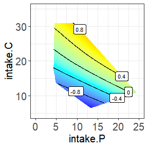

[output not shown]

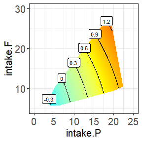

[output not shown]

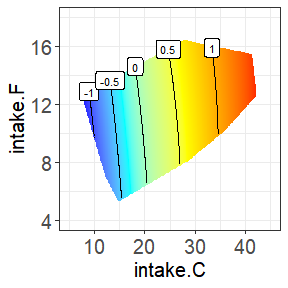

```r
NGFPlot(eNODAL_obj, "P19096", c("intake.P", "intake.C", "intake.F"))
```

We can also visualize the protein for each group, i.e. split by “Meta2”(Drug) and the resulting NGF are shown below.

[output not shown]

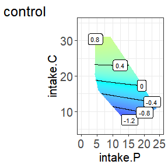

[output not shown]

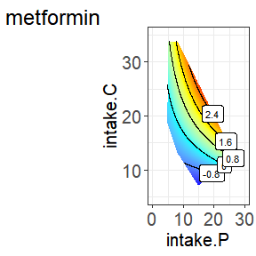

[output not shown]

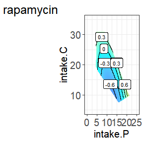

[output not shown]

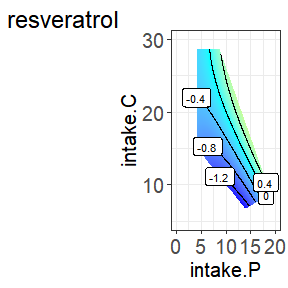

[output not shown]

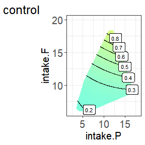

[output not shown]

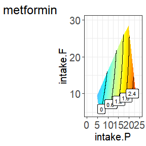

[output not shown]

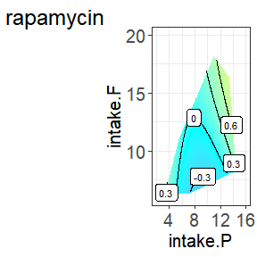

[output not shown]

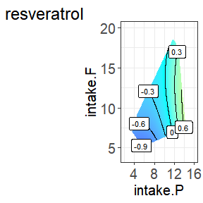

[output not shown]

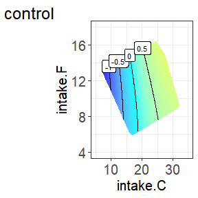

[output not shown]

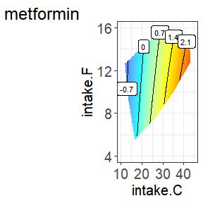

[output not shown]

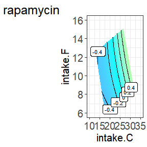

[output not shown]

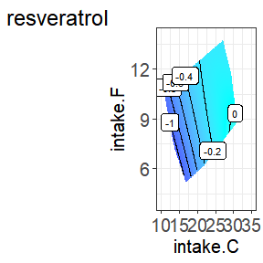

```r
NGFPlot(eNODAL_obj, "P19096", c("intake.P", "intake.C", "intake.F"), "Meta2")
```

We can also visualize the interpretable groups or subclusters by their first principal component.

[output not shown]

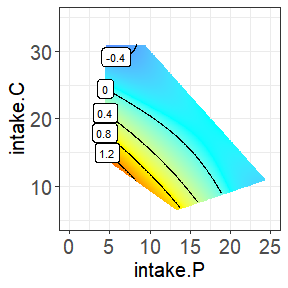

[output not shown]

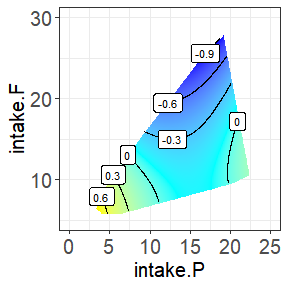

[output not shown]

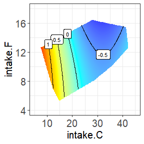

```r
NGFPlot(eNODAL_obj, "Meta1_C1", c("intake.P", "intake.C", "intake.F"))
```

## Boxplot

For discrete variable, we can visualize by boxplot

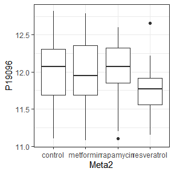

```r
Boxplot(eNODAL_obj, "Meta2", "P19096")
```